# Model Building

Aboubakar Hameed

18/02/2022

```r
library(tidyverse)
library(lubridate)
library(leaps)
library(caret)
```

# 1 MPV

## 1.1 Loading dataset

```r
avocados <- read_csv("data/avocado.csv")
avocados
```

| ...1 | Date | AveragePrice | Total Volume | 4046 | 4225 | 4770 | Total Bags | Small Bags | Large Bags | XLarge Bags | type | year | region |
| --- | --- | --- | --- | --- | --- | --- | --- | --- | --- | --- | --- | --- | --- |
| 0 | 2015-12-27 | 1.33 | 64236.62 | 1036.74 | 54454.85 | 48.16 | 8696.87 | 8603.62 | 93.25 | 0.00 | conventional | 2015 | Albany |
| 1 | 2015-12-20 | 1.35 | 54876.98 | 674.28 | 44638.81 | 58.33 | 9505.56 | 9408.07 | 97.49 | 0.00 | conventional | 2015 | Albany |
| 2 | 2015-12-13 | 0.93 | 118220.22 | 794.70 | 109149.67 | 130.50 | 8145.35 | 8042.21 | 103.14 | 0.00 | conventional | 2015 | Albany |
| 3 | 2015-12-06 | 1.08 | 78992.15 | 1132.00 | 71976.41 | 72.58 | 5811.16 | 5677.40 | 133.76 | 0.00 | conventional | 2015 | Albany |
| 4 | 2015-11-29 | 1.28 | 51039.60 | 941.48 | 43838.39 | 75.78 | 6183.95 | 5986.26 | 197.69 | 0.00 | conventional | 2015 | Albany |
| 5 | 2015-11-22 | 1.26 | 55979.78 | 1184.27 | 48067.99 | 43.61 | 6683.91 | 6556.47 | 127.44 | 0.00 | conventional | 2015 | Albany |
| 6 | 2015-11-15 | 0.99 | 83453.76 | 1368.92 | 73672.72 | 93.26 | 8318.86 | 8196.81 | 122.05 | 0.00 | conventional | 2015 | Albany |
| 7 | 2015-11-08 | 0.98 | 109428.33 | 703.75 | 101815.36 | 80.00 | 6829.22 | 6266.85 | 562.37 | 0.00 | conventional | 2015 | Albany |
| 8 | 2015-11-01 | 1.02 | 99811.42 | 1022.15 | 87315.57 | 85.34 | 11388.36 | 11104.53 | 283.83 | 0.00 | conventional | 2015 | Albany |
| 9 | 2015-10-25 | 1.07 | 74338.76 | 842.40 | 64757.44 | 113.00 | 8625.92 | 8061.47 | 564.45 | 0.00 | conventional | 2015 | Albany |

[output cut: 9990 more lines]

```r
glimpse(avocados)
```

```
## Rows: 18,249
## Columns: 14
## $ ...1           <dbl> 0, 1, 2, 3, 4, 5, 6, 7, 8, 9, 10, 11, 12, 13, 14, 15, 1…
## $ Date           <date> 2015-12-27, 2015-12-20, 2015-12-13, 2015-12-06, 2015-1…
## $ AveragePrice   <dbl> 1.33, 1.35, 0.93, 1.08, 1.28, 1.26, 0.99, 0.98, 1.02, 1…
## $ `Total Volume` <dbl> 64236.62, 54876.98, 118220.22, 78992.15, 51039.60, 5597…
## $ `4046`         <dbl> 1036.74, 674.28, 794.70, 1132.00, 941.48, 1184.27, 1368…
## $ `4225`         <dbl> 54454.85, 44638.81, 109149.67, 71976.41, 43838.39, 4806…
## $ `4770`         <dbl> 48.16, 58.33, 130.50, 72.58, 75.78, 43.61, 93.26, 80.00…
## $ `Total Bags`   <dbl> 8696.87, 9505.56, 8145.35, 5811.16, 6183.95, 6683.91, 8…
## $ `Small Bags`   <dbl> 8603.62, 9408.07, 8042.21, 5677.40, 5986.26, 6556.47, 8…
## $ `Large Bags`   <dbl> 93.25, 97.49, 103.14, 133.76, 197.69, 127.44, 122.05, 5…
## $ `XLarge Bags`  <dbl> 0.00, 0.00, 0.00, 0.00, 0.00, 0.00, 0.00, 0.00, 0.00, 0…
## $ type           <chr> "conventional", "conventional", "conventional", "conven…
## $ year           <dbl> 2015, 2015, 2015, 2015, 2015, 2015, 2015, 2015, 2015, 2…
## $ region         <chr> "Albany", "Albany", "Albany", "Albany", "Albany", "Alba…
```

```r
#Tidy up data. changing region, type and month as factor, as they are categorical number. Also will extract month as factor from date since we have year column.

tidy_avocados <- avocados %>%
  mutate(
         #month = as.factor(month(Date)),
         year = as.factor(year),
        # region = as.factor(region),
         type = as.factor(type)
         ) %>%
  select(-...1, -Date, -region) %>%
  janitor::clean_names()

tidy_avocados  %>%
  dim()
```

```
## [1] 18249    11
```

```r
regsubsets_forward <- regsubsets(average_price ~ ., data = tidy_avocados, nvmax = 10, method = "forward")
```

```r
sum_regsubsets_forward <- summary(regsubsets_forward)
sum_regsubsets_forward
```

```
## Subset selection object
## Call: regsubsets.formula(average_price ~ ., data = tidy_avocados, nvmax = 10,
##     method = "forward")
## 12 Variables  (and intercept)
##              Forced in Forced out
## total_volume     FALSE      FALSE
## x4046            FALSE      FALSE
## x4225            FALSE      FALSE
## x4770            FALSE      FALSE
## total_bags       FALSE      FALSE
## small_bags       FALSE      FALSE
## large_bags       FALSE      FALSE
## x_large_bags     FALSE      FALSE
## typeorganic      FALSE      FALSE
## year2016         FALSE      FALSE
## year2017         FALSE      FALSE
## year2018         FALSE      FALSE
## 1 subsets of each size up to 10
## Selection Algorithm: forward
##           total_volume x4046 x4225 x4770 total_bags small_bags large_bags
## 1  ( 1 )  " "          " "   " "   " "   " "        " "        " "
## 2  ( 1 )  " "          " "   " "   " "   " "        " "        " "
## 3  ( 1 )  " "          "*"   " "   " "   " "        " "        " "
## 4  ( 1 )  " "          "*"   "*"   " "   " "        " "        " "
## 5  ( 1 )  " "          "*"   "*"   " "   " "        " "        " "
## 6  ( 1 )  " "          "*"   "*"   " "   " "        " "        " "
## 7  ( 1 )  " "          "*"   "*"   "*"   " "        " "        " "
## 8  ( 1 )  " "          "*"   "*"   "*"   " "        " "        "*"
## 9  ( 1 )  " "          "*"   "*"   "*"   " "        " "        "*"
## 10  ( 1 ) " "          "*"   "*"   "*"   " "        "*"        "*"
##           x_large_bags typeorganic year2016 year2017 year2018
## 1  ( 1 )  " "          "*"         " "      " "      " "
## 2  ( 1 )  " "          "*"         " "      "*"      " "
## 3  ( 1 )  " "          "*"         " "      "*"      " "
## 4  ( 1 )  " "          "*"         " "      "*"      " "
## 5  ( 1 )  " "          "*"         "*"      "*"      " "
## 6  ( 1 )  "*"          "*"         "*"      "*"      " "
## 7  ( 1 )  "*"          "*"         "*"      "*"      " "
## 8  ( 1 )  "*"          "*"         "*"      "*"      " "
## 9  ( 1 )  "*"          "*"         "*"      "*"      "*"
## 10  ( 1 ) "*"          "*"         "*"      "*"      "*"
```

To decide how many variables to pick, will plot the adjusted r2

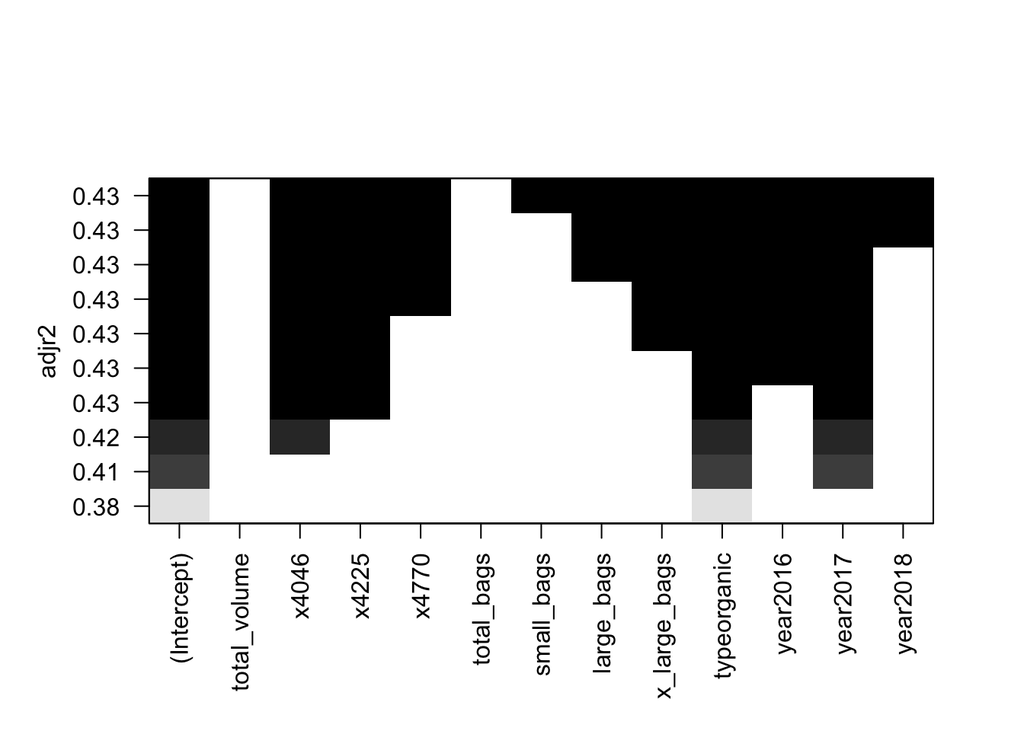

```r
plot(regsubsets_forward, scale = "adjr2")
```

From the plot below the r2 is increases as the number of predictors in the model increases, but fromthe last 2 or 3 the predictors stay the same.

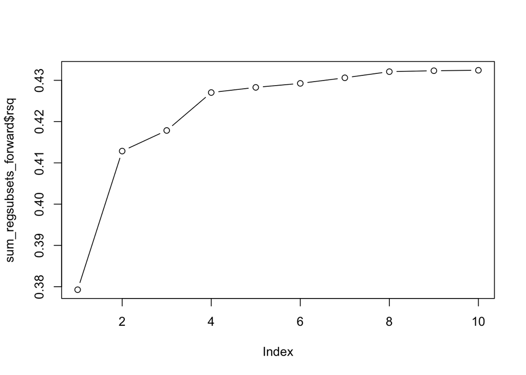

```r
plot(sum_regsubsets_forward$rsq, type = "b")
```

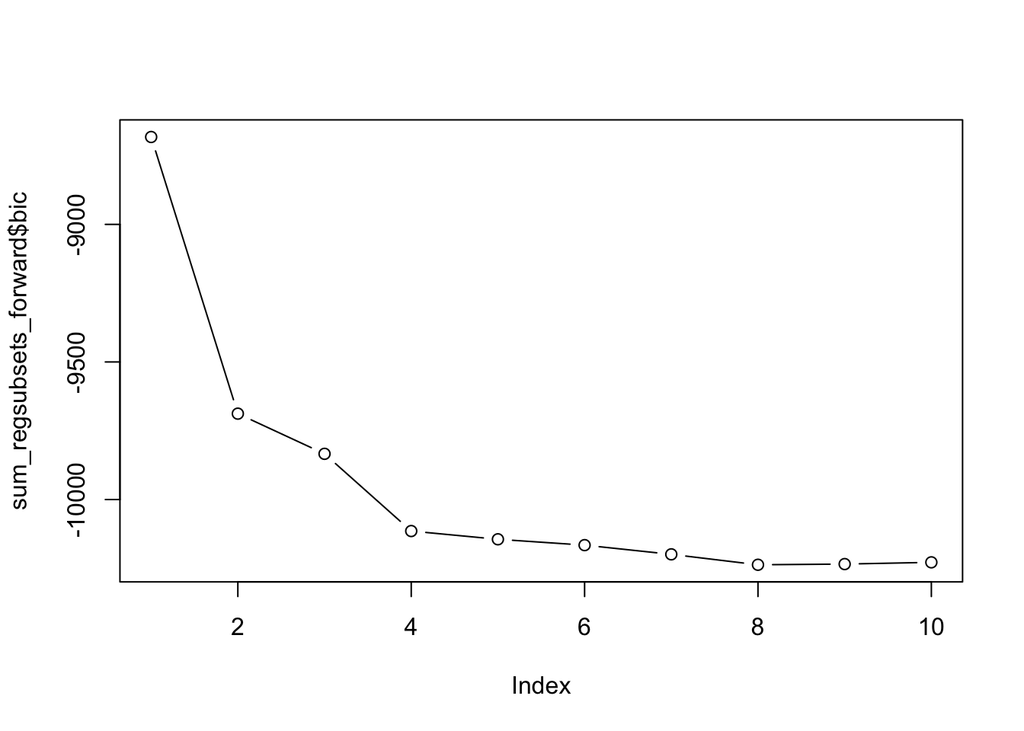

```r
plot(sum_regsubsets_forward$bic, type = "b")
```

```r
summary(regsubsets_forward)$which[6,]
```

```
##  (Intercept) total_volume        x4046        x4225        x4770   total_bags
##         TRUE        FALSE         TRUE         TRUE        FALSE        FALSE
##   small_bags   large_bags x_large_bags  typeorganic     year2016     year2017
##        FALSE        FALSE         TRUE         TRUE         TRUE         TRUE
##     year2018
##        FALSE
```

# From the summaray above and the adjr2 plot we can see that these the best predictions of our model with True (x4046,x4225,XLarge Bags, typeorganic, year2016 and year2017).

Now will use K-fold cross validation to evaluate our model, will set K = 10 in our test.

```r
cv_10_fold <- trainControl(method = "cv", # cross-validation
                           number = 10, # 10-fold
                           savePredictions = TRUE)

model <- train(average_price ~ x4046 + x4225 + x_large_bags + type + year,
               data = tidy_avocados,
               trControl = cv_10_fold, # use options defined above
               method = 'lm')

summary(model)
```

```
##
## Call:
## lm(formula = .outcome ~ ., data = dat)
##
## Residuals:
##      Min       1Q   Median       3Q      Max
## -1.32353 -0.18402 -0.01794  0.17705  1.66614
##
## Coefficients:
##                Estimate Std. Error t value Pr(>|t|)
## (Intercept)   1.137e+00  4.794e-03 237.133  < 2e-16 ***
## x4046        -1.044e-07  4.848e-09 -21.540  < 2e-16 ***
## x4225         8.100e-08  5.033e-09  16.095  < 2e-16 ***
## x_large_bags  1.053e-06  1.816e-07   5.799 6.78e-09 ***
## typeorganic   4.882e-01  4.633e-03 105.371  < 2e-16 ***
## year2016     -4.189e-02  5.765e-03  -7.266 3.86e-13 ***
## year2017      1.381e-01  5.752e-03  24.007  < 2e-16 ***
## year2018     -2.771e-02  9.410e-03  -2.945  0.00324 **
## ---
## Signif. codes:  0 '***' 0.001 '**' 0.01 '*' 0.05 '.' 0.1 ' ' 1
##
## Residual standard error: 0.3042 on 18241 degrees of freedom
## Multiple R-squared:  0.4295, Adjusted R-squared:  0.4293
## F-statistic:  1962 on 7 and 18241 DF,  p-value: < 2.2e-16
```

we will extract the all predictions from our model:

```r
model$pred
```

| pred | obs | rowIndex | intercept | Resample |
| --- | --- | --- | --- | --- |
| 1.1441329 | 0.98 | 8 | TRUE | Fold01 |
| 1.1413833 | 1.33 | 20 | TRUE | Fold01 |
| 1.1440743 | 1.12 | 21 | TRUE | Fold01 |
| 1.1424469 | 1.26 | 24 | TRUE | Fold01 |
| 1.1420248 | 1.27 | 28 | TRUE | Fold01 |
| 1.1439213 | 1.07 | 30 | TRUE | Fold01 |
| 1.1424274 | 1.43 | 33 | TRUE | Fold01 |
| 1.1394082 | 1.20 | 35 | TRUE | Fold01 |
| 1.1388291 | 0.99 | 47 | TRUE | Fold01 |
| 1.1405745 | 0.99 | 48 | TRUE | Fold01 |

[output cut: 9990 more lines]

The error across each fold in the model

```r
model$resample
```

| RMSE | Rsquared | MAE | Resample |
| --- | --- | --- | --- |
| 0.3037572 | 0.4329186 | 0.2317937 | Fold01 |
| 0.2984788 | 0.4376644 | 0.2285612 | Fold02 |
| 0.3141575 | 0.4048285 | 0.2396616 | Fold03 |
| 0.3078647 | 0.4201182 | 0.2329206 | Fold04 |
| 0.3031715 | 0.4297278 | 0.2300227 | Fold05 |
| 0.2965495 | 0.4436428 | 0.2268022 | Fold06 |
| 0.3070754 | 0.4324200 | 0.2314898 | Fold07 |
| 0.3034282 | 0.4346810 | 0.2297969 | Fold08 |
| 0.3003136 | 0.4408976 | 0.2273394 | Fold09 |
| 0.3068269 | 0.4188316 | 0.2319490 | Fold10 |

In order to compare our models with all prediction mpdel,we need to calculate the average error and the average r-squared values:

```r
mean(model$resample$RMSE)
```

```
## [1] 0.3041623
```

```r
mean(model$resample$Rsquared)
```

```
## [1] 0.429573
```

In order to ccompare the average error and the average r-squared values with the model which has all the variables will do the test below:

```r
cv_10_fold <- trainControl(method = "cv",
                           number = 10,
                           savePredictions = TRUE)

model <- train(average_price ~ .,
               data = tidy_avocados,
               trControl = cv_10_fold,
               method = 'lm')

mean(model$resample$RMSE)
```

```
## [1] 0.3035207
```

```r
mean(model$resample$Rsquared)
```

```
## [1] 0.4319998
```

# 2 conclusion:

This is not our expect, as the well fitted model we did has a higher error and a lower r-squared value than the one with all the predictors these results almost the same which are too close to each others, so that the model is stable, but not acceptable model. I think to make our model even better, we might need to include more predictors or variables.

Notice: I decide to remove region and month from the model as end up with too many dummy variables.